# R Notebook

## Introduction

Climate change is one of the most important challenges in the world today. Understanding how greenhouse gases, especially carbon dioxide (CO2), are related to changes in global temperatures is key to studying this problem. Carbon dioxide levels have been increasing because of human activities, and researchers continue to study how this impacts global temperatures. In this project, we look at the relationship between global atmospheric CO2 levels and changes in global temperatures. Our findings may prove the factor that CO2 levels have on the increase of global temperatures and if a decrease in CO2 levels may help the climate change issue. We ask one main question: Is there a strong link between CO2 levels and changes in global temperatures over time? By studying monthly CO2 data from the Mauna Loa Observatory and temperature data from NASA’s Goddard Institute for Space Studies, we aim to find patterns and trends in how CO2 levels affect global temperatures and if it is a big factor in climate change.

## Backround

To answer our question, we need the global atmospheric CO2 concentration for each month and the corresponding global temperature anomaly. Thus, our dataset consists of data from two sources.

**CO2 Data (co2-mm-mlo.csv):** The CO2 data is collected by the Mauna Loa Observatory using infrared gas analyzers, providing monthly averages adjusted to remove outliers and ensure precision. Each row represents the average CO2 concentration (in ppm) for a specific month.

**Temperature Data (monthly.csv):** The temperature anomaly data is from NASA’s Goddard Institute for Space Studies (GISS) and it represents the deviation from a baseline average (1951–1980) and is calculated using station and satellite records. Each row corresponds to a month’s global temperature anomaly (in °C).

**Combined Data:** We want to determine whether there is a significant correlation between CO2 concentrations and global temperature anomalies over time and to explore how this relationship changes. To address these questions, a scatter plot with CO2 concentration on the x-axis and temperature anomaly on the y-axis will be used, complemented by a linear regression line to highlight trends. Simple linear regression will serve as our primary method for quantifying this relationship.

Some limitations may impact our analysis. Monthly rather than annual data may introduce noise, and global averages may overlook regional variations. Despite these challenges, our analysis seeks meaningful insights into the relationship between atmospheric CO2 levels and global temperatures, contributing to the broader understanding of climate change worldwide.

## Statistical Analysis

```r
knitr::opts_chunk$set(
  echo = FALSE,
  error = FALSE,
  fig.height = 3,
  message = FALSE,
  warning = FALSE
)
library(tidyverse)
```

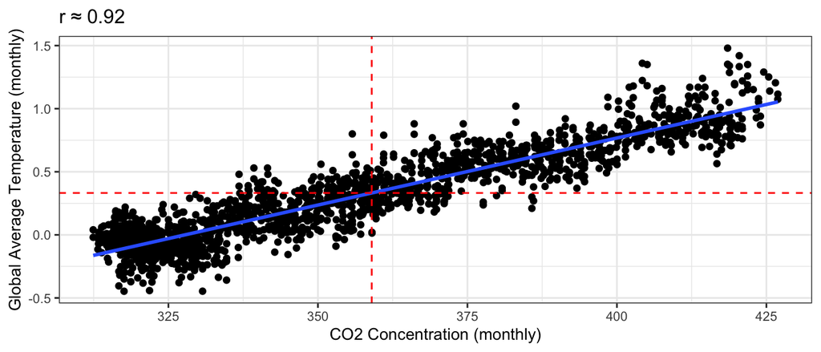

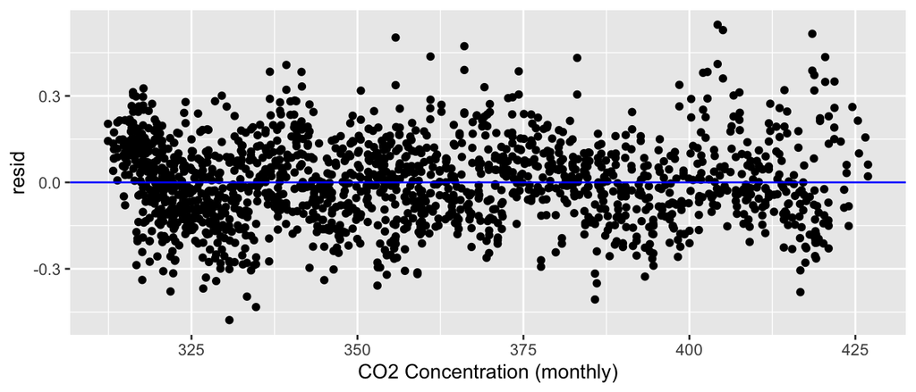

```
## [1] 0.01035802 0.01089846
```

Confidence Interval: (0.01035802 0.01089846)

Hypothesis test H0: slope = 0 HA: slope != 0

```
## [1] "P-Value: 0"
```

p-value: 0 (extremely small, so r rounds it to 0)

## Discussion

Both the confidence interval (excluding 0) and the p-value suggest a significant positive relationship between CO2 levels and temperature anomalies. This aligns with the general scientific understanding that greenhouse gases are a primary driver of climate change. Our model quantifies this relationship, suggesting that small increases in CO2 can lead to measurable rises in global temperatures. We hope that governmental policy makers continue to make efforts to limit climate change.

**Limitations:** Our analysis has its limitations, our use of monthly averages and global data may obscure some short-term fluctuations and regional differences. The model assumes a linear relationship, though climate dynamics may be more complex. Additionally, other factors influencing temperature, such as volcanic activity and solar radiation, are not included. While the model fits the data well, predictions beyond observed CO2 levels should be treated with caution.

**Future Analysis:** Future analyses could explore regional differences, potential non-linear relationships, and the role of other greenhouse gases like methane and nitrous oxide. Even with these limitations, our analysis provides strong evidence of the impact of CO2 emissions on global temperatures, which shows the urgent need to make changes limiting CO2 emissions even further. We would also like to research the CO2 emmisions in different areas and see their effects on the global temperture.